# Natal Solidário Floripa TI

# **Primeiros passos com Python**

Matheus Braun Magrin

braunmagrin@gmail.com

09 de Dezembro de 2016

# Python e eu

- Me chamo **Matheus Braun Magrin**
- Fiz **Ciência da Computação** na UFSC
- Trabalho como **Cientista de dados na Bravi**
- **2+ anos trabalhando com Python** (5+ anos usando)

# Por que Python?

Python é uma linguagem **simples**, **bonita** e de **fácil aprendizado** que se presta as mais diversas tarefas, desde **scripts para automação** de tarefas do dia a dia, à **computação científica**, passando por **desenvolvimento Web** e **análise de dados**.

É **software livre** e é **gratuita** ;)

# Conhecendo a linguagem

- Alto nível
- Interpretada
- Tipagem dinâmica

```python
import random
z = random.choice(['aha', 1])
```

# Conhecendo a linguagem

- Alto nível
- Interpretada
- Tipagem dinâmica
- Multi paradigma
  - Orientada a objetos

```python
class MinhaClasse:
    pass

obj = MinhaClasse()
type(obj)
```

```
__main__.MinhaClasse
```

# Conhecendo a linguagem

- Alto nível
- Interpretada
- Tipagem dinâmica
- Multi paradigma
  - Orientada a objetos
  - Funcional

```python
# functools: Higher-order functions and operations on callable objects
import functools
add = lambda x,y: x + y
add_one = functools.partial(add, 1)

add_one(1)
```

```
2
```

```python
functools.reduce(f3, filter(f2, map(f1, sequence)))
```

# Conhecendo a linguagem

## Filosofia

```python
import this
```

```
The Zen of Python, by Tim Peters

Beautiful is better than ugly.
Explicit is better than implicit.
Simple is better than complex.
Complex is better than complicated.
Flat is better than nested.
Sparse is better than dense.
Readability counts.
Special cases aren't special enough to break the rules.
Although practicality beats purity.
Errors should never pass silently.
Unless explicitly silenced.
In the face of ambiguity, refuse the temptation to guess.
There should be one-- and preferably only one --obvious way to do it.
Although that way may not be obvious at first unless you're Dutch.
Now is better than never.
Although never is often better than *right* now.
If the implementation is hard to explain, it's a bad idea.
If the implementation is easy to explain, it may be a good idea.
Namespaces are one honking great idea -- let's do more of those!
```

Se tudo isso parece um pouco obscuro, dê uma olhada [nessa apresentação](http://artifex.org/~hblanks/talks/2011/pep20_by_example.pdf).

Eles mostram exemplos do que fazer e não fazer segundo esses princípios para ter um código melhor.

# Comunidade

- Comunidade extremamente receptiva
- https://wiki.python.org/moin/DiversityInPython

> Resumo da minha [@pythonbrasil](https://twitter.com/pythonbrasil) e de minha semana em Florianópolis [#pybr12](https://twitter.com/hashtag/pybr12?src=hash) [#oktoberpython](https://twitter.com/hashtag/oktoberpython?src=hash) num sticker muito bem bolado [pic.twitter.com/gNyzWIH6Wa](https://t.co/gNyzWIH6Wa)

> — Fernando Masanori (@fmasanori) [October 19, 2016](https://twitter.com/fmasanori/status/788725570909659136)

# Antes de começarmos com a sintaxe

Algumas coisas a se ter em mente:

- Indentação importa!

```python
def f(x):
    value = x * 5
  return value
```

[output not shown]

# Antes de começarmos com a sintaxe

Algumas coisas a se ter em mente:

- Indentação importa!
- Tudo é objeto

```python
i = 6
i.__add__(2)
```

```
8
```

```python
i.__add__
```

```
<method-wrapper '__add__' of int object at 0x9a3480>
```

# Tipos básicos

- Números

```python
i = 1 # int
f = .5 # float
```

# Tipos básicos

- Números
- Strings

```python
s = 'a' # str
s = 'aha' # str
```

# Tipos básicos

- Números
- Strings
- Booleanos

```python
b = False # bool
b = True # bool
```

# Tipos básicos

- Números
- Strings
- Booleanos
- None

```python
n = None
type(n)
```

```
NoneType
```

# Operadores

Vou listar aqui apenas os que são diferentes de linguagens como Java, C#:

- Lógicos: `and`, `or`, `not`
- Identidade: `is`, `is not`
- Pertencimento: `in`, `not in`

```python
if item not in sequence:
    do_something_about_it()

if obj is not None:
    do_something_about_it()
```

# Estruturas de dados

- Lista

```python
l = [] # list()
l = ['aha', 6, []]
l.append(1) # mutável
```

```python
show_public_attributes(list)
```

```
'append, clear, copy, count, extend, index, insert, pop, remove, reverse, sort'
```

# Estruturas de dados

- Lista
- Tupla

```python
t = (1, 2) # imutável
```

# Estruturas de dados

- Lista
- Tupla
- Dicionário

```python
d = {} # dict()
d = {'aha': 1, 'uhu': 6}
d['ehe'] = 8 # mutável
```

```python
show_public_attributes(dict)
```

```
'clear, copy, fromkeys, get, items, keys, pop, popitem, setdefault, update, values'
```

# Estruturas de dados

- Lista
- Tupla
- Dicionário
- Conjunto (*aquele da matemática mesmo*)

```python
set([1, 1, 1, 2, 2, 3])
```

```
{1, 2, 3}
```

```python
show_public_attributes(set)
```

```
'add, clear, copy, difference, difference_update, discard, intersection, intersection_update, isdisjoint, issubset, issuperset, pop, remove, symmetric_difference, symmetric_difference_update, union, update'
```

# Formatando strings

É possível usar variáveis do nosso programa para montar strings.

Exemplos:

```python
lista = [1, 2, 3, 4]
print('Essa lista tem {} items'.format(len(lista)))
```

```
Essa lista tem 4 items
```

```python
from math import pi
print('Vamos ver PI com apenas 4 casas decimais: {:.4f}'.format(pi)) # limita as casas decimais
```

```
Vamos ver PI com apenas 4 casas decimais: 3.1416
```

Muitos outros exemplos em: https://pyformat.info/

# Fatiando sequências (*Slicing*)

É possível pegar partes de um sequência com a seguinte sintaxe:

```
sequencia[inicio:fim:passo]
```

Alguns exemplos:

```python
s = 'abcdef'

s[1:] # a partir do segundo elemento
```

```
'bcdef'
```

```python
s[-3:] # últimos 3 elementos
```

```
'def'
```

```python
s[::2] # pegar elementos intercalados
```

```
'ace'
```

```python
s[::-1] # inverter a lista, percorrendo-a com um passo negativo
```

```
'fedcba'
```

# Estruturas de controle

# Condicionais

```python
if tem_duvidas():
    publico.levanta_a_mao_e_pergunta()
else:
    continuamos()
```

- Operador ternário

```python
publico.levanta_a_mao_e_pergunta() if tem_duvidas() else continuamos()
```

# Laços

```python
for item in sequence:
    faca_alguma_coisa(item)
```

```python
while valor < limite:
    transforme(valor)
```

- `break`: para o loop atual
- `continue`: passa para a próxima iteração do loop

# Definindo Funções

```python
def f(x, y=1): # y tem um valor padrão
    return x * y

f(2)
```

```
2
```

```python
f(2, 2)
```

```
4
```

# Definindo Funções

- Funções anônimas (`lambda`)

```python
lambda x, y: x + y
```

```
<function __main__.<lambda>>
```

Caso mais comum de uso é criar funções anônimas e já as passar como parâmetro para outras funções

```python
list(map(lambda x: 2 ** x, range(8)))
```

```
[1, 2, 4, 8, 16, 32, 64, 128]
```

# Classes

```python
class A:
    def __init__(self):
        self.text = 'aha'


class B(A):
    def __init__(self):
        super().__init__()

    def mostre(self):
        print(self.text)


b = B()
b.mostre()
```

```
aha
```

# Classes - Atributos e métodos privados

```python
class B(A):
    def __init__(self):
        super().__init__()
        self._atributo_privado = 1 # new

    def mostre(self):
        print(self.text)

    # new
    def _metodo_privado(self):
        print('Shhhhh')


b = B()
b._metodo_privado()
```

```
Shhhhh
```

Python não impede o acesso, usar `_` para marcar como privado é apenas uma convenção.

Serve apenas para indicar aos outros programadores que eles não deveriam acessar aquela propriedade.

# Classes - Convenções

```python
', '.join(dir(A))
```

```
'__class__, __delattr__, __dict__, __dir__, __doc__, __eq__, __format__, __ge__, __getattribute__, __gt__, __hash__, __init__, __le__, __lt__, __module__, __ne__, __new__, __reduce__, __reduce_ex__, __repr__, __setattr__, __sizeof__, __str__, __subclasshook__, __weakref__'
```

Métodos como `__init__` (com dois *underscores* na frente e atrás) são outra convenção, para indicar métodos especiais ([Docs:*Special method names*)](https://docs.python.org/3.4/reference/datamodel.html#specialnames)

Exemplo: quando chamamos `a == b`, o que acontece é equivalente a `a.__eq__(b)`

# Classes - Outro uso dos *underscores*

```python
class B(A):
    def __init__(self):
        super().__init__()
        self._atributo_privado = 1

    def mostre(self):
        print(self.text)
        self.__nome_estranho() # new

    def _metodo_privado(self):
        print('Shhhhh')

    # new
    def __nome_estranho(self):
        print('Funciona')

b = B()
b.mostre()
```

```
aha
Funciona
```

# Classes - Outro uso dos *underscores*

```python
b.__nome_estranho()
```

```
---------------------------------------------------------------------------
AttributeError                            Traceback (most recent call last)
<ipython-input-66-f51fb735ec25> in <module>()
----> 1 b.__nome_estranho()

AttributeError: 'B' object has no attribute '__nome_estranho'
```

```python
', '.join(dir(b))
```

[output not shown]

# Comprehensions

*Comprehensions* são uma maneira especial de criar coleções

A sintaxe genérica é:

```
[... for ... in ... if ...]
```

sendo o `if` opcional

```python
l = [2 ** x for x in range(8)]
l = [obj.atributo for obj in sequencia if obj] # is not None
```

```python
l = list(map(lambda x: 2 ** x, range(8)))
l = map(lambda x: x.atributo, filter(lambda x: x, sequencia))
```

```python
d = {x: y for x, y in zip(xs, ys)}
```

# Iterador (*iterator*)

Um objeto que permite iterar sobre uma sequência.

Toda vez que usamos um `for`, o Python cria um `iterator` para a sequência que passarmos

As funções `map`, `filter` e outras do módulo `itertools` retornam `iterators`

# Geradores (*generators*)

São uma ferramenta para criar `iterators`

```python
def infinito(start=0):
    x = start
    while True:
        yield x
        x += 1

inf_gen = infinito()
```

```python
next(inf_gen)
```

```
0
```

```python
next(inf_gen)
```

```
1
```

```python
type(inf_gen)
```

```
generator
```

# Expressões geradoras (*Generators Expressions*)

Sintaxe semelhante a *list comprehension* porém usando parênteses

Tende a consumir menos memória, pois gera os elementos sob-demanda

```python
g = (x for x in range(8) if x % 2 == 0)
g
```

```
<generator object <genexpr> at 0x7f43f6da4f30>
```

```python
type(g)
```

```
generator
```

# Decorators

- Função que altera o comportamento da função/classe "decorada"

# Decorators

Como usar um `decorator` já pronto

```python
from functools import lru_cache

@lru_cache(maxsize=None)
def fib(n):
    if n < 2:
        return n
    return fib(n-1) + fib(n-2)
```

```python
[fib(n) for n in range(16)]
```

```
[0, 1, 1, 2, 3, 5, 8, 13, 21, 34, 55, 89, 144, 233, 377, 610]
```

```python
fib.cache_info()
```

```
CacheInfo(hits=28, misses=16, maxsize=None, currsize=16)
```

# Decorators

Como criar um `decorator` (usando um `decorator`)

```python
from functools import wraps
def my_decorator(f):
    @wraps(f)
    def wrapper(*args, **kwds):
        print('Calling decorated function')
        return f(*args, **kwds)
    return wrapper

@my_decorator
def example():
    """Docstring"""
    print('Called example function')

example()
```

```
Calling decorated function
Called example function
```

É uma boa prática usar `functools.wraps` ao criar `decorators` pois assim se preservam as propriedades da função original, e.g. `__name__` e `__doc__`

Exemplos tirados de: https://docs.python.org/3/library/functools.html#functools.wraps

# Tratamento de exceções

```python
try:
    operacao_arriscada()
except:
    lide_com_o_problema()
```

# Monkey Patching

```python
def monkey():
    from IPython.display import HTML
    return HTML('<img src="images/sir.jpg" width="350px">')

b.monkey = monkey
```

```python
b.monkey()
```

[figure not shown]

# O interpretador

`$ python`

```python
dir()
```

```python
help()
```

```
Welcome to Python 3.4's help utility!

If this is your first time using Python, you should definitely check out
the tutorial on the Internet at http://docs.python.org/3.4/tutorial/.

Enter the name of any module, keyword, or topic to get help on writing
Python programs and using Python modules.  To quit this help utility and
return to the interpreter, just type "quit".

To get a list of available modules, keywords, symbols, or topics, type
"modules", "keywords", "symbols", or "topics".  Each module also comes
with a one-line summary of what it does; to list the modules whose name
or summary contain a given string such as "spam", type "modules spam".

help> keywords

Here is a list of the Python keywords.  Enter any keyword to get more help.

False               def                 if                  raise
None                del                 import              return
True                elif                in                  try
and                 else                is                  while
as                  except              lambda              with
assert              finally             nonlocal            yield
break               for                 not
class               from                or
continue            global              pass

help> quit

You are now leaving help and returning to the Python interpreter.
If you want to ask for help on a particular object directly from the
interpreter, you can type "help(object)".  Executing "help('string')"
has the same effect as typing a particular string at the help> prompt.
```

# Baterias inclusas - Biblioteca padrão

- [Python Module Index](https://docs.python.org/3.4/py-modindex.html)

## Alguns pacotes importantes

- os
- sys
- re
- json
- doctest
- unittest
- collections
- itertools
- functools
- logging
- random

# Ecosistema - Pacotes

- [PyPI - the Python Package Index](https://pypi.python.org/pypi)
- Atualmente existem 94333 pacotes no PyPI

## Alguns pacotes importantes

- ipython
- jupyter
- requests
- begins, docopt
- pandas
- numpy, numba
- scipy
- matplotlib, seaborn, bokeh
- beautifulsoup4
- flask, django, pyramid
- scikit-learn
- theano, tensorflow, keras

`$pip install ipython`

# Virtualenvs

São ambientes isolados, para facilitar trabalhar com diferentes versões de bibliotecas na mesma máquina

```
$ pip install virtualenvwrapper
```

Com o `virtualenvwrapper` instalado, fica bastante fácil criar, ativar e desativar os `virtualenvs`

```
$ mkvirtualenv venv-name
(venv-name) $ pip install <>
(venv-name) $ deactivate
$ workon another-venv
(another-venv) $
```

# Aplicações

## Análise/Ciência de Dados

Fonte: http://scikit-learn.org/stable/auto_examples/plot_cv_predict.html#sphx-glr-auto-examples-plot-cv-predict-py

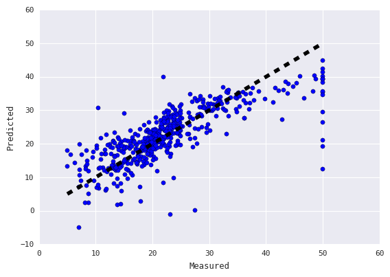

```python
from sklearn import datasets
from sklearn.model_selection import cross_val_predict
from sklearn import linear_model
import matplotlib.pyplot as plt

lr = linear_model.LinearRegression()

boston = datasets.load_boston()
y = boston.target

# cross_val_predict returns an array of the same size as `y` where each entry
# is a prediction obtained by cross validation:
predicted = cross_val_predict(lr, boston.data, y, cv=10)

fig, ax = plt.subplots()
ax.scatter(y, predicted)
ax.plot([y.min(), y.max()], [y.min(), y.max()], 'k--', lw=4)
ax.set_xlabel('Measured')
ax.set_ylabel('Predicted')
plt.show()
```

# Aplicações

## Visualização de dados

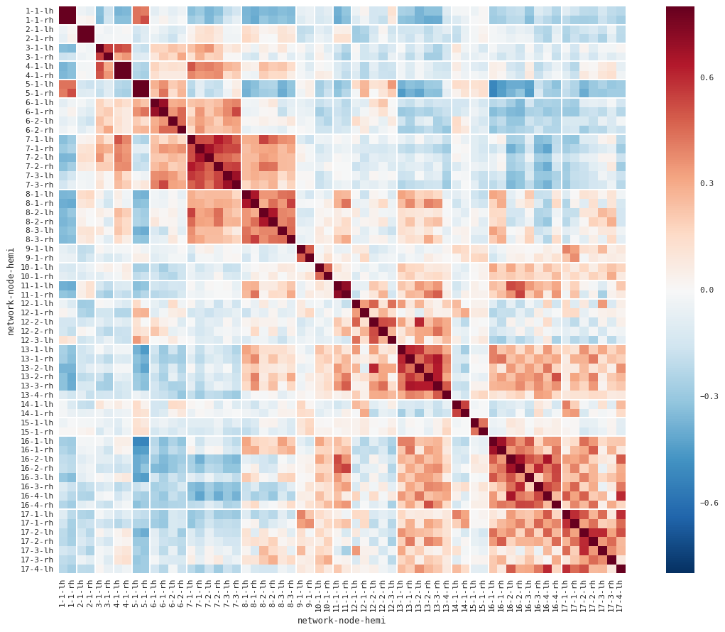

```python
import seaborn as sns
import matplotlib.pyplot as plt
sns.set(context="paper", font="monospace")

# Load the datset of correlations between cortical brain networks
df = sns.load_dataset("brain_networks", header=[0, 1, 2], index_col=0)
corrmat = df.corr()

# Set up the matplotlib figure
f, ax = plt.subplots(figsize=(12, 9))

# Draw the heatmap using seaborn
sns.heatmap(corrmat, vmax=.8, square=True)

# Use matplotlib directly to emphasize known networks
networks = corrmat.columns.get_level_values("network")
for i, network in enumerate(networks):
    if i and network != networks[i - 1]:
        ax.axhline(len(networks) - i, c="w")
        ax.axvline(i, c="w")
f.tight_layout()
```

# Aplicações

## Desenvolvimento Web

Uma aplicação web usando Flask e MySql Fonte: https://code.tutsplus.com/tutorials/creating-a-web-app-from-scratch-using-python-flask-and-mysql--cms-22972

```python
from flask import Flask, render_template, json, request
from flask.ext.mysql import MySQL
from werkzeug import generate_password_hash, check_password_hash

mysql = MySQL()
app = Flask(__name__)

# MySQL configurations
app.config['MYSQL_DATABASE_USER'] = 'jay'
app.config['MYSQL_DATABASE_PASSWORD'] = 'jay'
app.config['MYSQL_DATABASE_DB'] = 'BucketList'
app.config['MYSQL_DATABASE_HOST'] = 'localhost'
mysql.init_app(app)


@app.route('/')
def main():
    return render_template('index.html')

@app.route('/showSignUp')
def showSignUp():
    return render_template('signup.html')


@app.route('/signUp',methods=['POST','GET'])
def signUp():
    try:
        _name = request.form['inputName']
        _email = request.form['inputEmail']
        _password = request.form['inputPassword']

        # validate the received values
        if _name and _email and _password:

            # All Good, let's call MySQL

            conn = mysql.connect()
            cursor = conn.cursor()
            _hashed_password = generate_password_hash(_password)
            cursor.callproc('sp_createUser',(_name,_email,_hashed_password))
            data = cursor.fetchall()

            if len(data) is 0:
                conn.commit()
                return json.dumps({'message':'User created successfully !'})
            else:
                return json.dumps({'error':str(data[0])})
        else:
            return json.dumps({'html':'<span>Enter the required fields</span>'})

    except Exception as e:
        return json.dumps({'error':str(e)})
    finally:
        cursor.close()
        conn.close()

if __name__ == "__main__":
    app.run(port=5002)
```

```
 * Running on http://127.0.0.1:5002/ (Press CTRL+C to quit)
127.0.0.1 - - [09/Dec/2016 16:21:03] "GET / HTTP/1.1" 500 -
```

# Aplicações

## Facilitando a vida

**Cenário**: Um time fez uma reunião mas nem todos puderam participar. Era necessário enviar todas as cartas criadas durante a reunião em formato texto para os que faltaram.

[figure not shown]

```python
import json

with open('retro.json', 'r') as f:
    retro = json.load(f)
    lists_map = {l['id']: l['name'] for l in retro['lists']}
    cards = [{'text': card['name'], 'list': lists_map[card['idList']]}
             for card in retro['cards']]

    for l in lists_map.values():
        print(l)
        [print('  ' + c['text']) for c in cards if c['list'] == l]
        print()
```

```
Não funcionou
  Isso não foi legal
  Isso foi muito ruim
  Muito ruim
  Bem mais ou menos

Funcionou
  Isso foi bom
  Isso também
  Essa outra coisa também foi boa

Ações
  Melhorar isso
  Cuidar para não fazer aquilo
```

# Atividades práticas

## Codewars vs Coding Dojo

# Codewars

https://www.codewars.com/

Clan: NatalSolidario

https://www.codewars.com/collections/basic-python

# Coding Dojo

### [FizzBuzz](http://dojopuzzles.com/problemas/exibe/fizzbuzz/#)

Neste problema, você deverá exibir uma lista de 1 a 100, um em cada linha, com as seguintes exceções:

- Números divisíveis por 3 deve aparecer como 'Fizz' ao invés do número;
- Números divisíveis por 5 devem aparecer como 'Buzz' ao invés do número;
- Números divisíveis por 3 e 5 devem aparecer como 'FizzBuzz' ao invés do número'.

# Coding Dojo

### [Analisando URLs](http://dojopuzzles.com/problemas/exibe/analisando-urls/)

Dada uma URL, desenvolva um programa que indique se a URL é válida ou não e, caso seja válida, retorne as suas partes constituintes.

Exemplos:

- Entrada: http://www.google.com/mail/user=fulano
- Saída:
  - protocolo: http
  - host: www
  - domínio: google.com
  - path: mail
  - parâmetros: user=fulano
- Entrada: ssh://fulano%senha@git.com/
- Saída:
  - protocolo: ssh
  - usuário: fulano
  - senha: senha
  - dominio: git.com

# Dicas

## Gerais

- Leia o [The Python Tutorial](https://docs.python.org/3.4/tutorial/index.html)
- Leia, mesmo que por cima, [Module Index](https://docs.python.org/3/py-modindex.html), para saber o que existe na biblioteca padrão
- Leia o [Guia de estilo (PEP 8)](http://www.python.org/peps/pep-0008.html)

## Para o dia a dia

- Faça testes rápidos no interpretador
  - Use o `ipython` e não o `python`
- Use um linter (pep8 ou flake8) no seu editor

## Recursos

- Sites:
  - http://www.python.org
  - http://www.python.org.br
  - http://www.fullstackpython.com/
  - http://awesome-python.com/
  - [Visualize a execução do seu código com o "Python Tutor"](http://www.pythontutor.com/)
- Newsletter:
  - http://www.pythonweekly.com/
- Podcasts:
  - https://dbader.org/blog/ultimate-list-of-python-podcasts
- Comunidade:
  - Python Brasil: https://www.facebook.com/groups/python.brasil/?fref=ts
  - Python Floripa: https://www.facebook.com/groups/python.floripa/?fref=ts
- Encontros:
  - 16º Encontro Python Floripa - 15/12: https://www.facebook.com/events/1658617024436911/
- Vídeos:
  - [Pra quem gosta de Orientação a Objetos](https://www.youtube.com/watch?v=HTLu2DFOdTg)
- Textos:
  - [Uma introdução à programação funcional, usando Python como exemplo](https://maryrosecook.com/blog/post/a-practical-introduction-to-functional-programming)
  - [10 erros muito comuns ao usar Python](https://www.toptal.com/python/top-10-mistakes-that-python-programmers-make)

# Recursos

## Por que Python...

- para educação?
  - http://lorenabarba.com/blog/why-i-push-for-python/
- para cientistas?
  - https://www.stat.washington.edu/~hoytak/blog/whypython.html
- para Web?
  - https://www.fiveq.com/blog/programming/building-django-good-company/ (Django)
  - http://www.sixfeetup.com/blog/why-we-choose-python
- para qualquer pessoa?
  - https://automatetheboringstuff.com

### Referências

- [The Hitchhiker’s Guide to Python!](http://docs.python-guide.org/)
- [The Python Tutorial](https://docs.python.org/3.4/tutorial/index.html)
- [Como aprender Python para quem já sabe outras linguagens](https://wiki.python.org/moin/MovingToPythonFromOtherLanguages)
- [Python para Desenvolvedores](http://ricardoduarte.github.io/python-para-desenvolvedores/)
- [Fazendo slides com Jupyter (+ Python + Markdown + reveal.js)](http://www.damian.oquanta.info/posts/make-your-slides-with-ipython.html)

### Licença

O trabalho Primeiros Passos com Python de Matheus Braun Magrin está licenciado com uma Licença [Creative Commons - Atribuição-CompartilhaIgual 4.0 Internacional](http://creativecommons.org/licenses/by-sa/4.0/).  
O código usado para gerar essa apresentação está disponível em: https://github.com/braunmagrin/curso-python.

```python
import antigravity
```